# R Notebook

!!!!!!!!!!!!!!!!!!!!!!!!!!! Dimitrios Kalfountzos AEM 905 !!!!!!!!!!!!!!!!!!!! !!!!!!!!!!!!!!!!!!!!!!!!!!! LAB 03 !!!!!!!!!!!!!!!!!!!!!!!! ######################################################################

Lab 3: Simulations Create an R notebook with the following material and Solve the exercises

3 Simulations The ability to simulate different types of random data allows the user to perform experiments and answer questions in a rapid manner. It is a very useful skill to have, but is admittedly hard to learn.

How can we check this? Simulation is an excellent way.

Let’s investigate. How can we use R to create one of these random numbers?

```r
n=10;p=.25;S= rbinom(1,n,p)
(S - n*p)/sqrt(n*p*(1-p))
```

But that is only one of these random numbers. We really want lots of them to see their distribution. How can we create 100 of them? For this example, it is easy – we just take more samples in the rbinom function

```r
n = 10;p = .25;S = rbinom(100,n,p)
X = (S - n*p)/sqrt(n*p*(1-p)) # has 100 random number
```

The variable X has our results, and we can view the distribution of the random numbers in X with a histogram

```r
hist(X,prob=T)
```

[output not shown]

3.2 For loops In general, the mechanism to create the 100 random numbers, may not be so simple and we may need to create them one at a time. How to generate lots of these? We’ll use “for’’ loops which may be familiar from a previous computer class, although other R users might use apply or other tricks. The R command for iterates over some specified set of values such as the numbers 1 through 100. We then need to store the results somewhere. This is done using a vector and assigning each of its values one at a time.

Here is the same example using for loops:

```r
results =numeric(0)          # a place to store the results
for (i in 1:100)
  {           # the for loop
 S = rbinom(1,n,p)            # just 1 this time
 results[i]=(S- n*p)/sqrt(n*p*(1-p)) # store the answer
}
```

We create a variable results which will store our answers. Then for each i between 1 and 100, it creates a random number (a new one each time!) and stores it in the vector results as the ith entry. We can view the results with a histogram: hist(results).

R Basics: Syntax for for

A ``for’’ loop has a simple syntax: for(variable in vector) { command(s) } The braces are optional if there is only one command. The variable changes for each loop. Here are some examples to try

```r
primes=c(2,3,5,7,11);
## loop over indices of primes with this
for(i in 1:5) print(primes[i])
## or better, loop directly
for(i in primes) print(i)
```

Example: CLT with normal data

As above a for loop may be used

```r
results = c();
mu = 0; sigma = 1
for(i in 1:200) {
 X = rnorm(100,mu,sigma)       # generate random data
 results[i] = (mean(X) - mu)/(sigma/sqrt(100))
 }
hist(results,prob=T)
```

[output not shown]

3.3 Normal plots

A better plot than the histogram for deciding if random data is approximately normal is the so called “normal probability’’ plot. The basic idea is to graph the quantiles of your data against the corresponding quantiles of the normal distribution. The quantiles of a data set are like the Median and Q1 and Q3 only more general. The q quantile is the value in the data where q*100% of the data is smaller. So the 0.25 quantile is Q1, the 0.5 quantile is the median and the 0.75 quantile is Q3. The quantiles for the theoretical distribution are similar, only instead of the number of data points less, it is the area to the left that is the specified amount. For example, the median splits the area beneath the density curve in half.

The normal probability graph is easy to read – if you know how. Essentially, if the graph looks like a straight line then the data is approximately normal. Any curve can tell you that the distribution has short or long tails. It is not a regression line. The line is drawn through points formed by the first and third quantiles.

R makes all this easy to do with the functions qqnorm (more generally qqplot) and qqline which draws a reference line (not a regression line).

```r
x = rnorm(100,0,1);qqnorm(x,main='normal(0,1)');qqline(x)
x = rnorm(100,10,15);qqnorm(x,main='normal(10,15)');qqline(x)
x = rexp(100,1/10);qqnorm(x,main='exponential mu=10');qqline(x)
x = runif(100,0,1);qqnorm(x,main='unif(0,1)');qqline(x)
```

[output not shown]

3.4 Using simple.sim and functions This section shows how to write functions and how to use them with simple.sim. This is a little more complicated than most of the material in these notes and can be avoided if desired.

For purposes of simulation, it would be nice not to have to write a for loop each time. The function simple.sim is a function which does just that. You need to write a function that generates one of your random numbers, and then give it to simple.sim.

For example in checking the CLT for binomial data we needed to generate a single random number distributed as a standardized binomial number. A function to do so is:

```r
f = function () {
S = rbinom(1,n,p)
(S- n*p)/sqrt(n*p*(1-p))
}
```

With this function, we could use simple.sim like this:

```r
library(UsingR)
x=simple.sim(100,f)
hist(x)
##### distixws m vgazei afto to sfalma "Error in simple.sim(100, f) : could not find function "simple.sim"
```

This replaces the need to write a ``for loop’’ and also makes the simulations consistent looking. Once you’ve written the function to create a single random number the rest is easy.

While we are at it, we should learn the “right” way to write functions. We should be able to modify n the number of trials and p the success probability in our function. So f is better defined as

```r
f = function(n=100,p=.5) {
S = rbinom(1,n,p)
(S- n*p)/sqrt(n*p*(1-p))
}
```

The format for the variable is n=100 this says that n is the first variable given to the function, by default it is 100, p is the second by default it is p=.5. Now we would call simple.sim as

```r
library(UsingR)
simple.sim(1000,f,100,.5)
### pali afto to paliominima Error in simple.sim(1000, f, 100, 0.5) :
## could not find function "simple.sim"
```

So the trick is to learn how to write functions to create a single number. The appendix contains more details on writing functions. For immediate purposes the important things to know are Functions have a special keyword function as in

```r
the.range = function (x) max(x) - min(x)
```

which returns the range of the vector x. (Already available with range.) This tells R that the.range is a function, and its arguments are in the braces. In this case (x). If a function is a little more complicated and requires multiple commands you use braces (like a for loop). The last value computed is returned. This example finds the IQR based on the lower and upper hinges and not the quantiles. It uses the results of the fivenum command to get the hinges

```r
find.IQR = function(x) {
  five.num = fivenum(x)         # for Tukey's summary
  five.num[4] - five.num[2]
}
```

The plus sign indicates a new line and is generated by R – you do not need to type it. (The five number summary is 5 numbers: the minimum, the lower hinges, the median, the upper hinge, and the maximum. This function subtracts the second from the fourth.) A function is called by its name and with parentheses. For example

```r
x = rnorm(100)               # some sample data
find.IQR                     # oops! no argument. Prints definition.
function(x) {
  five.num = fivenum(x)
  five.num[4] - five.num[2]
}
find.IQR(x)                  # this is better
```

Here are some more examples.

Example: A function to sum normal numbers To find the standardized sum of 100 normal(0,1) numbers we could use

```r
f = function(n=100,mu=0,sigma=1) {
   nos = rnorm(n,mu,sigma)
   (mean(nos)-mu)/(sigma/sqrt(n))
}
```

Then we could use simple.sim as follows

```r
simulations = simple.sim(100,f,100,5)
library(UsingR)
hist(simulations,breaks=10,prob=TRUE)
```

[output not shown]

Example: CLT with exponential data Let’s do one more example. Suppose we start with a skewed distribution, the central limit theorem says that the average will eventually look normal. That is, it is approximately normal for large n. What does `eventually'' mean? What does`large’’ mean? We can get an idea through simulation.

A example of a skewed distribution is the exponential. We need to know if it has mean 10, then the standard deviation is also 10, so we only need to specify the mean. Here is a function to create a single standardized average (note that the exponential distribution has theoretical standard deviation equal to its mean)

```r
f = function(n=100,mu=10) (mean(rexp(n,1/mu))-mu)/(mu/sqrt(n))
```

Now we simulate for various values of n. For each of these m=100 (the number of random numbers generated), but n varies from 1,5,15 and 50 (the number of random numbers in each of our averages).

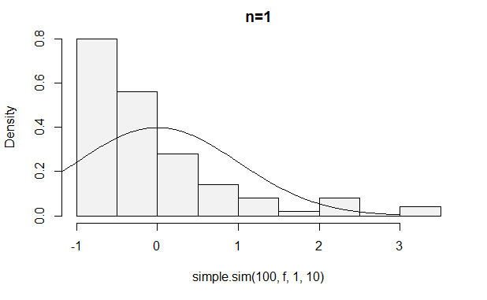

```r
xvals = seq(-3,3,.01) # for the density plot
library(UsingR)
hist(simple.sim(100,f,1,10),probability=TRUE,main="n=1",col=gray(.95))
points(xvals,dnorm(xvals,0,1),type="l") # plot normal curve
```

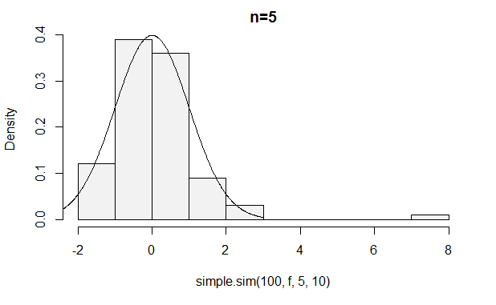

```r
#  ... repeat for n=5,15,50
### for n = 15!!!!!!###
xvals = seq(-3,3,.01) # for the density plot
library(UsingR)
hist(simple.sim(100,f,5,10),probability=TRUE,main="n=5",col=gray(.95))
points(xvals,dnorm(xvals,0,1),type="l") # plot normal curve
```

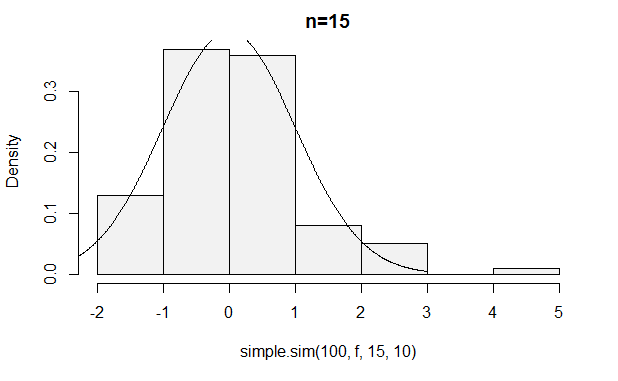

```r
#  ... repeat for n=5,15,50
### for n = 15 !!! ###
xvals = seq(-3,3,.01) # for the density plot
library(UsingR)
hist(simple.sim(100,f,15,10),probability=TRUE,main="n=15",col=gray(.95))
points(xvals,dnorm(xvals,0,1),type="l") # plot normal curve
```

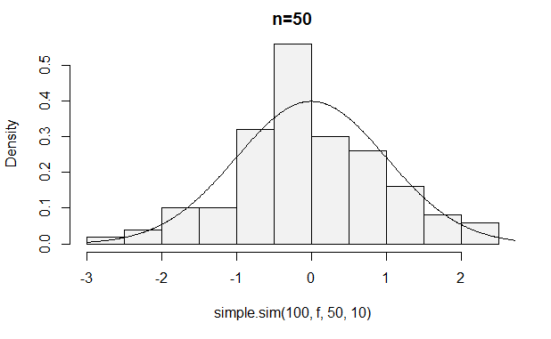

```r
#  ... repeat for n=5,15,50
### for n = 50 #####
xvals = seq(-3,3,.01) # for the density plot
library(UsingR)
hist(simple.sim(100,f,50,10),probability=TRUE,main="n=50",col=gray(.95))
points(xvals,dnorm(xvals,0,1),type="l") # plot normal curve
```

```r
#  ... repeat for n=5,15,50
```

Figure 34: Simulation of CLT with exponential data. Note it is not perfectly bell shaped.

The histogram becomes very bell shaped between n=15 and n=50, although even at n=50 it appears to still be a little skewed.

3.5 Problems

7.1 Do two simulations of a binomial number with n=100 and p=.5. Do you get the same results each time? What is different? What is similar?

```r
n = 100
p = 0.5
S1 <- rbinom(1000,n,p)
S2 <- rbinom(1000,n,p)
X1 <- (S1 - n*p)/sqrt(n*p*(1-p))
X2 <- (S2 - n*p)/sqrt(n*p*(1-p))
par(mfrow=c(1,2), oma=c(0,0,2,0))
hist(X1, col=gray(.9), prob=T, main="S1")
lines(density(X1, adjust=2), col="red")
```

```r
hist(X2, col=gray(.9), prob=T, main="S2")
lines(density(X2, adjust=2), col="red")
```

[figure not shown]

```r
title("7.1 - Binomial Simulation Comparison", outer=T)
```

```r
#dev.copy(png, "images/7-1.png")
#dev.off()
#  ... S1 and S2 will yield different sets of numbers,
#      so their respective density graphs will be different.
#      range and shape should be similar, however...
```

```r
n = 10
m1 = 10
s1 = 10
m2 = 100
s2 = 100
S1 <- rnorm(10, m1, s1)
S2 <- rnorm(10, m2, s2)
par(mfrow=c(1,2), oma=c(0,0,2,0))
qqnorm(S1, main="S1")
qqline(S1, col="red")
```

```r
qqnorm(S2, main="S2")
qqline(S2, col="red")
```

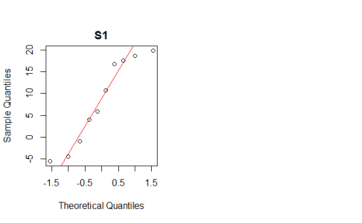

```r
title("7.2 - Normal Simulation Comparison", outer=T)
```

```r
n = 100
f <- function(n=100, p=.5)
{
    S <- rbinom(1,n,p)
    (S - n*p)/sqrt(n*p*(1-p))
}
S1 <- simple.sim(1000,f,n,.25)
S2 <- simple.sim(1000,f,n,.05)
S3 <- simple.sim(1000,f,n,.01)
par(mfrow=c(1,3), oma=c(0,0,2,0))
hist(S1, col=gray(.9), prob=T, main="S1: p=0.25")
lines(density(S1, adjust=2), col="blue")
```

```r
hist(S2, col=gray(.9), prob=T, main="S2: p=0.05")
lines(density(S2, adjust=2), col="blue")
```

```r
hist(S3, col=gray(.9), prob=T, main="S3: p=0.01")
lines(density(S3, adjust=2), col="blue")
```

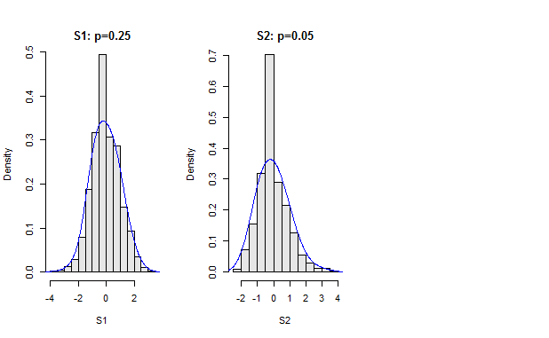

```r
title("7.3 - Bernoulli Simulations, p=.25, .05, .01", outer=T)
```

```r
#  ... nai, mporei kaneis na dei, pws h distribution-katanomh
# einai peripou idia gia tis prosomoiwseis S1 kai S2
# kai epeita paei pros ta katw gia tin S3
```

7.4 The normal plot is a fancy way of checking if the distribution looks normal. A more primitive one is to check the rule of thumb that 68% of the data is 1 standard deviation from the mean, 95% within 2 standard deviations and 99.8% within 3 standard deviations.

Create 100 random numbers when the Xi are normal with mean 0 and standard deviation 1. What percent are within 1 standard deviation of the the mean? Two standard deviations, 3 standard deviations? Is your data consistent with the normal?

(Hint: The data is supposed to have mean 0 and variance 1. To check for 1 standard deviation we can do

> k = 1;sigma = 1 n = length(x) sum( -k*sigma <x & x< k*sigma)/n Read the & as “and” and this reads as – after simplification– ``-1 less than x and x less than 1’’. This is the same as P(-1<x<1).)

```r
m = 0
s = 1
x <- rnorm(100,m,s)
f <- function(X,k=1,s=1)
{
    sum(-k*s < X & X < k*s)/length(X)
}
f(x,1,s)
```

```
[1] 0.74
```

```r
f(x,2,s)
```

```
[1] 0.96
```

```r
f(x,3,s)
```

```
[1] 0.99
```

7.5 It is interesting to graph the distribution of the standardized average as n increases. Do this when the Xi are uniform on [0,1]. Look at the histogram when n is 1, 5, 10 and 25. Do you see the normal curve taking shape?

(A rule of thumb is that if the Xi are not too skewed, then n>25 should make the average approximately normal. You might want

> f=function(n,a=0,b=1) { mu=(b+a)/2 sigma=(b-a)/sqrt(12) (mean(runif(n,a,b))-mu)/(sigma/sqrt(n)) } where the formulas for the mean and standard deviation are given. )

```r
#  ... this is a continuous uniform distribution
#      c.f. http://en.wikipedia.org/wiki/Uniform_distribution_(continuous))
f <- function(n, a=0, b=1)
{
    m <- (b+a)/2
    s <- (b-a)/sqrt(12)
    (mean(runif(n,a,b))-m)/(s/sqrt(n))
}
X1 <- simple.sim(100,f,1)
X5 <- simple.sim(100,f,5)
X10 <- simple.sim(100,f,10)
X25 <- simple.sim(100,f,25)
par(mfrow=c(2,2), oma=c(0,0,2,0))
hist(X1, col=gray(.9), prob=T, main="n=1")
lines(density(X1, adjust=2), col="blue")
```

```r
hist(X5, col=gray(.9), prob=T, main="n=5")
lines(density(X5, adjust=2), col="blue")
```

```r
hist(X10, col=gray(.9), prob=T, main="n=10")
lines(density(X10, adjust=2), col="blue")
```

```r
hist(X25, col=gray(.9), prob=T, main="n=25")
lines(density(X25, adjust=2), col="blue")
```

[figure not shown]

```r
title("7.5 - Uniform Dist. Simulations: n=1, 5, 10, 25", outer=T)
```

7.6 A home movie can be made by automatically showing a sequence of graphs. The system function System.sleep can insert a pause between frames. This will show a histogram of the sampling distribution for increasingly large n

> for (n in 1:50) { + results = c() + mu = 10;sigma = mu + for(i in 1:200) { + X = rexp(200,1/mu) + results[i] = (mean(X)-mu)/(sigma/sqrt(n)) + } + hist(results) + Sys.sleep(.1) + }

Run this code and take a look at the movie. To rerun, you can save these lines into a function or simply use the up arrow to recall the previous set of lines. What do you see?

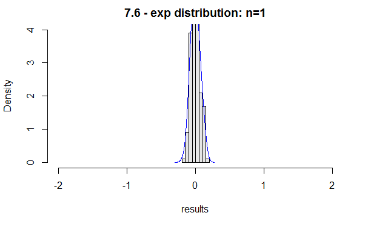

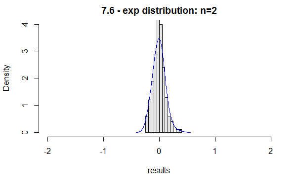

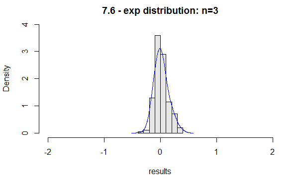

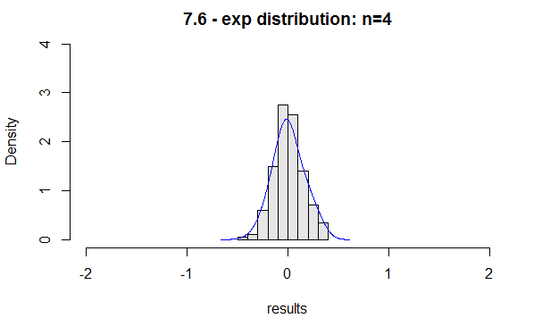

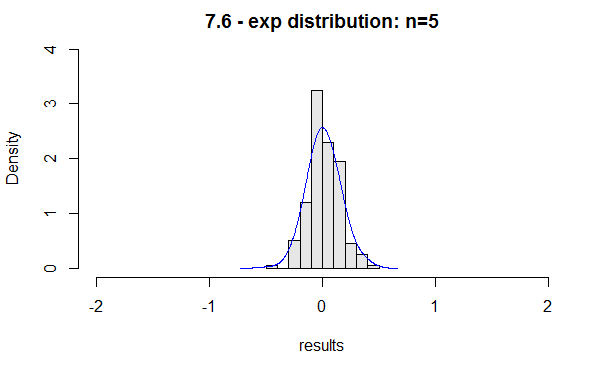

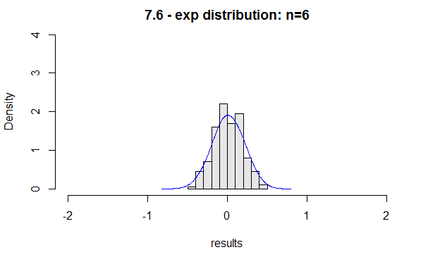

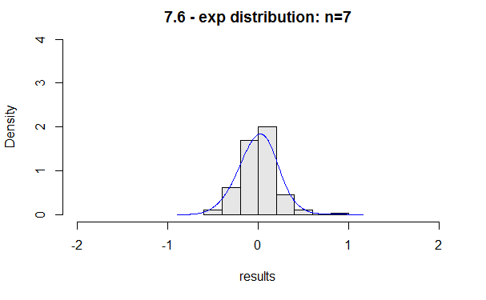

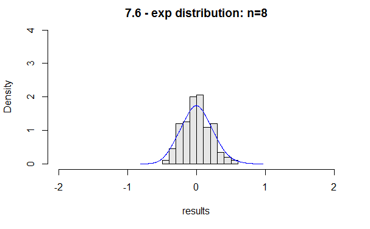

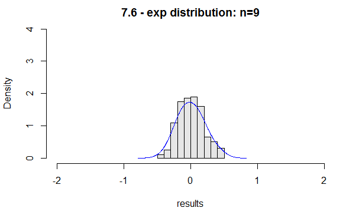

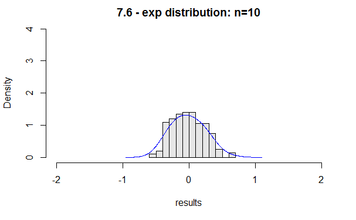

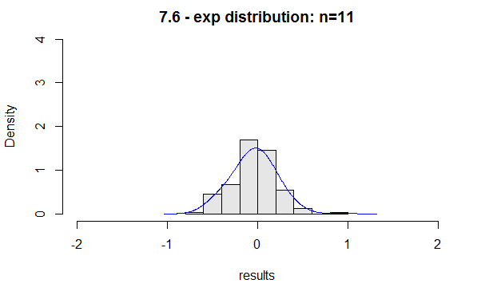

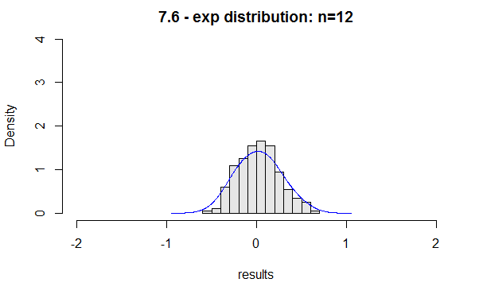

[38 more figures not shown]

```r
f <- function()
{
    for (n in 1:50) {
        results = c()
        mu = 10;sigma = mu
        for (i in 1:200) {
            X = rexp(200,1/mu)
            results[i] = (mean(X)-mu)/(sigma/sqrt(n))
        }
        hist(results,
         prob=T,
         col=gray(.9),
         xlim=c(-2, 2),
         ylim=c(0, 4),
         main=paste("7.6 - exp distribution: n=", as.character(n), sep=""))
    lines(density(results, adjust=2), col="blue")
        Sys.sleep(1)
    }
}
f()
```

7.7 Make normal graphs for the following random distributions. Which of them (if any) are approximately normal? 1. rt(100,4) 2. rt(100,50) 3. rchisq(100,4) 4. rchisq(100,50)

```r
par(mfrow=c(2,2), oma=c(0,0,2,0))
R1 <- rt(100,4)
R2 <- rt(100,50)
R3 <- rchisq(100,4)
R4 <- rchisq(100,50)
qqnorm(R1, main="rt(100, 4)")
qqline(R1, col="red")
```